# H4

Exercise 1 Not completed

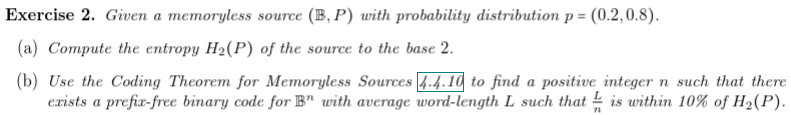

(a): $H_b(P) = \sum_{p\in P}p\log_b(\frac{1}{p})$

$$ 0.2 \log_2(5) + 0.8 \log_2(1.25)= 0.722 $$

(b) Using 4.4.10 a binary PF code exists such that for any integer $n$ such that $n \geq \frac{1}{\epsilon}$,

$$ \frac{L}{n} < H_2(P) + \epsilon $$

For a code with average codeword length divided by n $L/n$ to be within 10% of $H_2(P)$, choose $\epsilon = 0.1*H_2(P)$

$$ \epsilon = 0.1*H_2(P) = 0.0722 \\ n \geq \frac{1}{\epsilon} = 13.9 \\ n \geq 14 $$

$$ \frac{L}{n} < 1.1*H_2(P) = 0.79\\ \frac{L}{0.79} < n $$

Choose $n$ such that $n > \frac{L}{0.79}$ and $n \geq 14$

```python
z1 = '00100101'
z2 = '10111001'

def rat_num(z):
    zsum = 0
    for i, z in enumerate(z):
        zsum += int(z)/(2**(i+1))
    return zsum

print(rat_num(z1))
print(rat_num(z2))
```

```
0.14453125
0.72265625
```

For $z = 00100101$: $0_*z = 0.14453125$

For $z = 10111001$: $0_*z = 0.72265625$

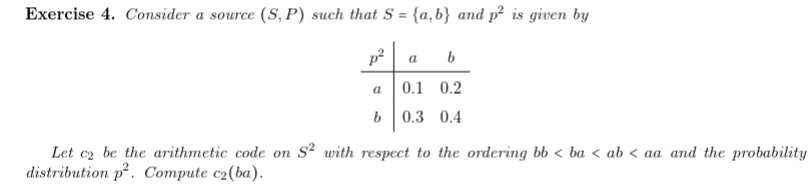

$$ n'(ba) = \left\lceil \log_2\left(\frac{1}{0.3}\right)\right\rceil = 2 \\ \alpha(ba) = p(bb) = 0.4 \\ c'(ba) = \left\lceil 2^{n'(ba)+1}\alpha(ba)\right\rceil = \left\lceil 8*0.4\right\rceil = 4 \\ c_2(ba) = 100 $$

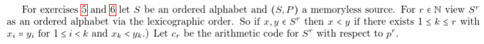

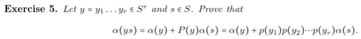

Not Completed.

Using definition 4.5.1

$$ \alpha(s) = \sum_{t\in S,t<s} p_t $$

For multimple terms $\alpha(s_1s_2\dots)$ I have no idea what happens

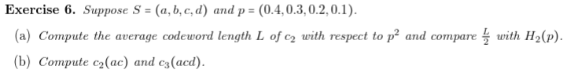

Let's make a function which generates the arithmatic code

```python
from math import log2, ceil

def arithmatic_code(ordered_prob):
    acode = []
    alpha = 0
    for p in ordered_prob:
        nprime = ceil(log2(1/p))
        cprime = ceil(2**(nprime+1)*alpha)
        codeword = bin(cprime)[2:]
        adjusted_codeword = '0'*((nprime+1)-len(codeword)) + codeword

        acode.append(adjusted_codeword)
        alpha += p
    return acode

pdist = (0.4, 0.3, 0.2, 0.1)

arithmatic_code(pdist)
```

```
['000', '100', '1100', '11101']
```

Great! Now the rest is easy.

(a) $L_{p^2}(c_2) = 0.4*3+0.3*3+0.2*4+0.1*5=3.4$

Compared to $H_2(p) = 1.846$, our $L/2 = 1.7$ is just slightly lower

(b) $c_2(ac) = 00011000$ and $c_3(acd) = 0001100011101$

```python
from other_code import get_entropy

get_entropy(pdist, base=2)
```

```
1.8464393446710154
```

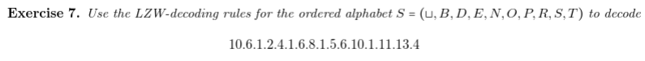

Our initial dictionary is

$$ \left[ \begin{matrix} m+k \\ d_{m+k} \\ \end{matrix} \left| \, \begin{matrix} \sqcup & B & D & E & N &O&P&R&S&T\\ 1 & 2 & 3 & 4&5&6&7&8&9&10\\ \end{matrix} \right. \right] $$

Since the largest codeword is 13, we can use our code to expand this

$$ \left[ \begin{matrix} m+k \\ d_{m+k} \\ \end{matrix} \left| \, \begin{matrix} \sqcup & B & D & E & N &O&P&R&S&T&TO&O\sqcup&\sqcup B\\ 1 & 2 & 3 & 4&5&6&7&8&9&10&11&12&13\\ \end{matrix} \right. \right] $$

|10 T|6 O|1 $\sqcup$|2 B|4 E|1 $\sqcup$|6 O|8 R|1 $\sqcup$|5 N|6 O|10 T|1 $\sqcup$|11 TO|13 $\sqcup$ B|4 E|

TO BE OR NOT TO BE

The initial dictionary is

$$ \left[ \begin{matrix} m+k \\ d_{m+k} \\ \end{matrix} \left| \, \begin{matrix} I & M & P & S\\ 1 & 2 & 3 & 4\\ \end{matrix} \right. \right] $$

During encoding this becomes

$$ \left[ \begin{matrix} m+k \\ d_{m+k} \\ \end{matrix} \left| \, \begin{matrix} I & M & P & S & MI & IS & SS& SI& ISS& SIP&PP&PI\\ 1 & 2 & 3 & 4 & 6 & 7 & 8 & 9 & 10 & 11&12&13\\ \end{matrix} \right. \right] $$

|M|I|S|S|IS|SI|P|P|I|

becomes 214479331, or more accurately

2.1.4.4.7.9.3.3.1